# FAQs

# Treatment of mediators for causal inference

Assume the following causal model:

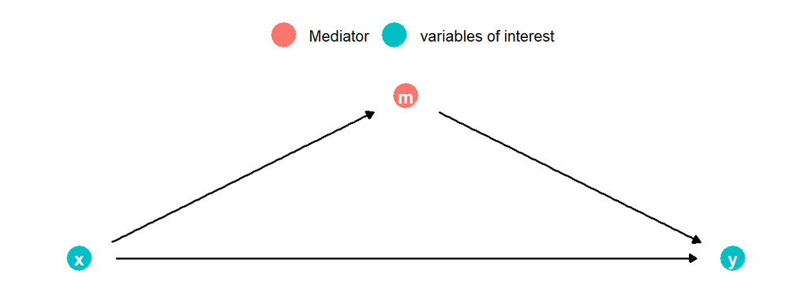

```r
library(ggdag)
library(tidyverse)
library(dagitty)
library(patchwork)
med2 <- dagify(m ~ x, y ~ m + x,
  coords = list(x = c(x = 1, m = 1.5, y = 2), y = c(x = 1, y = 1, m = 1.5))
) |>
  tidy_dagitty() |>
  mutate(fill = ifelse(name == "m", "Mediator", "variables of interest")) |>
  ggplot(aes(x = x, y = y, xend = xend, yend = yend)) +
  geom_dag_point(size = 7, aes(color = fill)) +
  geom_dag_edges(show.legend = FALSE) +
  geom_dag_text() +
  theme_dag() +
  theme(
    legend.title = element_blank(),
    legend.position = "top"
  )
med2
```

Data for such a situation can be generated as follows:

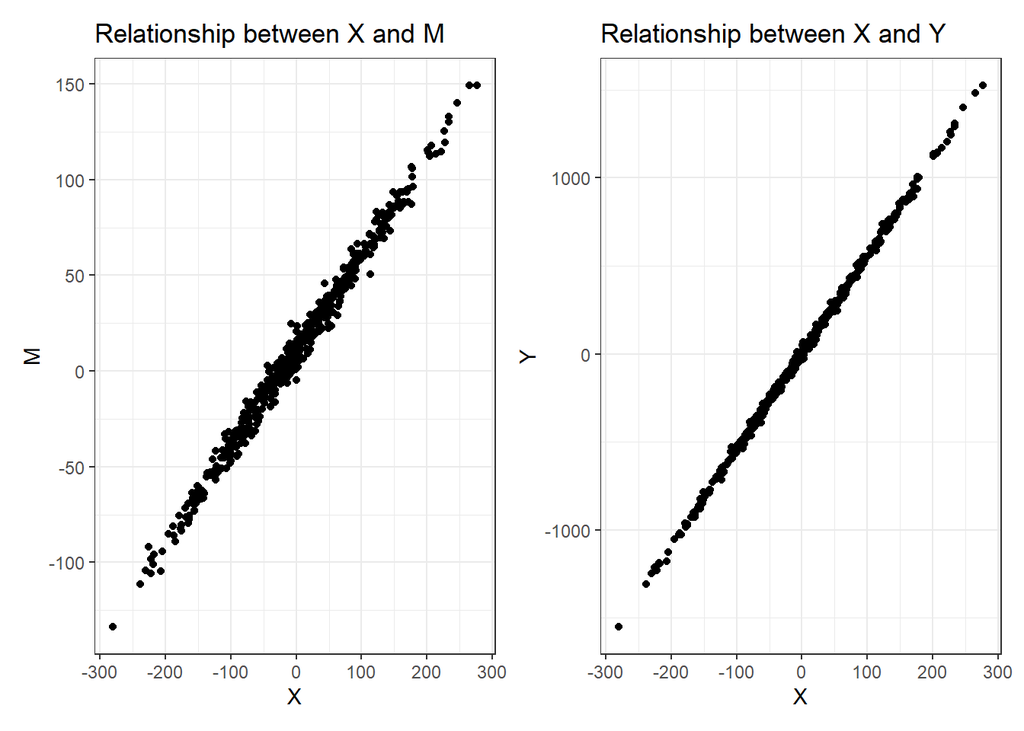

```r
set.seed(11)
n <- 500
X <- 100 * rnorm(n)
M <- 10 + 0.5 * X + 5 * rnorm(n)
Y <- -25 + 4 * X + 3 * M + 10 * rnorm(n)
df <- data.frame(X, M, Y)
ggplot(df, aes(x = X, y = M)) +
    geom_point() +
    theme_bw() +
    ggtitle("Relationship between X and M") +
ggplot(df, aes(x = X, y = Y)) +
    geom_point() +
    theme_bw() +
    ggtitle("Relationship between X and Y")
```

There are three options from a modeling perspective and which one we choose depends on the effect we are trying to measure.

1. **Avg. Direct effect** (lower edge): The average direct effect of $x$ on $y$ excluding the part mediated through $m$. If we are interested in the average direct effect, we include both $x$ and $m$ in the model to block the mediated path from $x$ to $y$ through $m$ (upper part of the DAG).

According to the data generationa above the average direct effect of $x$ on $y$ is $\sim4$. We identify this effect correctly with the full model:

```r
average_direct_effect <- lm(Y ~ X + M, data = df)
summary(average_direct_effect)
```

```
Call:
lm(formula = Y ~ X + M, data = df)

Residuals:
    Min      1Q  Median      3Q     Max
-38.528  -6.617   0.501   6.244  31.444

Coefficients:
             Estimate Std. Error t value Pr(>|t|)
(Intercept) -25.18109    1.02647  -24.53   <2e-16 ***
X             3.99450    0.04588   87.06   <2e-16 ***
M             3.00582    0.09102   33.02   <2e-16 ***
---
Signif. codes:  0 '***' 0.001 '**' 0.01 '*' 0.05 '.' 0.1 ' ' 1

Residual standard error: 10.2 on 497 degrees of freedom
Multiple R-squared:  0.9997,    Adjusted R-squared:  0.9996
F-statistic: 7.104e+05 on 2 and 497 DF,  p-value: < 2.2e-16
```

2. **Total effect** (lower and upper edges): The total effect of $x$ on $y$ including the part mediated through $m$. If we are not interested in the percentage of the effect mediated through $m$ (or we do not observe the mediator), we can simply omit $m$ from the model and estimate the simpler model:

```r
total_effect <- lm(Y ~ X, data = df)
summary(total_effect)
```

```
Call:
lm(formula = Y ~ X, data = df)

Residuals:
   Min     1Q Median     3Q    Max
-60.58 -11.14  -0.04  11.57  57.76

Coefficients:
            Estimate Std. Error t value Pr(>|t|)
(Intercept) 5.182230   0.814723   6.361 4.55e-10 ***
X           5.502025   0.008245 667.338  < 2e-16 ***
---
Signif. codes:  0 '***' 0.001 '**' 0.01 '*' 0.05 '.' 0.1 ' ' 1

Residual standard error: 18.22 on 498 degrees of freedom
Multiple R-squared:  0.9989,    Adjusted R-squared:  0.9989
F-statistic: 4.453e+05 on 1 and 498 DF,  p-value: < 2.2e-16
```

In order to convince ourselves that this is the correct total effect we need two figure out how much a unit change in $x$ affects $m$ and multiply that by the effect a change in $m$ has on $y$ (accounting for the first stage change in $x$). This is coincidentally also the third statistic we might be interested in.

3. **Avg. causal mediation effect** (upper part of DAG): We can estimate the average causal mediation effect by estimating two models separately (effect of $x$ on $m$ and effect of $m$ on $y$ given $x$) and multiplying the coefficients:

```r
average_causal_mediation_effect <- coef(lm(M ~ X, data = df))["X"] * # How much does the change in X affect M?
coef(lm(Y ~ X + M, data = df))["M"] # How much is the partial effect (accounting for x) of M on Y?
average_causal_mediation_effect
```

```
       X
1.507524
```

The total effect is equal to the sum of the average causal mediation effect and the average direct effect (sum of the upper and lower part of the DAG) and we can see that this is indeed the coefficient of the model without the mediator:

```r
average_causal_mediation_effect + coef(average_direct_effect)["X"]
```

```
       X
5.502025
```

```r
coef(total_effect)["X"]
```

```
       X
5.502025
```

Most of the time we are also interested in calculating the share of the total effect that is mediated through $m$:

```r
average_causal_mediation_effect / coef(total_effect)["X"]
```

```
        X
0.2739944
```

To summarize:

- Interest in **total effect**: include only $x$ in the model.
- Interest in **average direct effect**: include $x$ and $m$ in the model. We discussed one notable exception, [the post-treatment bias](https://wu-rds.github.io/storytelling/02-Modelling_MA.html#/common-bad-controls-cinelli2020crash), in which case including the mediator would bias the estimate of the effect of $x$ on $y$ since it opens a colliding path via the unobserved confounder ($U$). In this case we cannot identify the average direct effect but we can still identify the total effect.
- Interest in **disentangling** the **average causal mediation effect** and **average direct effect**: requires mediation analysis. In practice you want to use the `mediation` package or the [PROCESS macro by Andrew Hayes](https://wu-rds.github.io/storytelling/.CausalPitchfork.html#estimation-using-process) but a simple example is shown above.

## Fixed Effects

**Danger**

The term Fixed Effects is not used consistently in the literature. Here we view fixed effects as unit level constants (R packages: `fixest`, `lfe`, or `alpaca`). If you find the term “fixed effects” in the context of “mixed effects models” or “random effects models” (in R when the `lme4` package is used) it is not the same thing.

**Extremely simplified example**: We observe the streams (S) and number of playlist listings (P) for multiple songs (subscript $i$) on multiple days (subscript $t$). We want to estimate the effect of the number of playlist listings on the number of streams. We know that both consumers and playlist curators pick songs based on their (to us as reasearchers unobserved) quality (Q) and their danceability score (D) (both of which are constant for each song). In addition, consumers follow playlists to discover music. A DAG for this model would look like this:

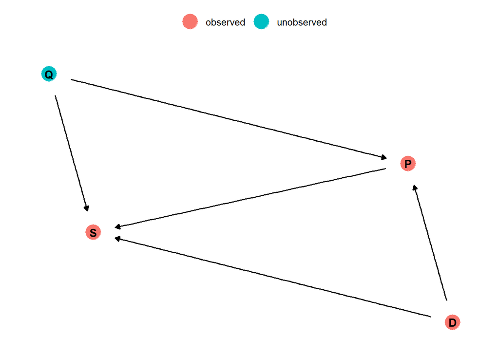

```r
dag_fixed_effects <- dagitty("dag {
  S [streams]
  P [playlist listings]
  Q [quality]
  D [danceability]
  D -> S
  D -> P
  Q -> S
  Q -> P
  P -> S
}")
dag_fixed_effects |>
 tidy_dagitty() |>
 mutate(obs = case_when(name == "S" ~ "observed",
                        name == "P" ~ "observed",
                        name == "D" ~ "observed",
                        name == "Q" ~ "unobserved")) |>
  ggplot(aes(x = x, y = y, xend = xend, yend = yend, color = obs)) +
  geom_dag_point(size = 7) +
  geom_dag_edges(show.legend = FALSE) +
  geom_dag_text(col = "black") +
  theme_dag() +
  theme(
    legend.title = element_blank(),
    legend.position = "top"
  )
```

**Problem**: We have unobserved confounders at a unit level. In our case that is the quality of a song. Not including “quality” in the model will bias the estimate of the effect of playlist listings on streams (omitted variable bias).

**Solution**: Add song fixed effects to the model. The fixed effect takes care of all unobserved unit (song) level confounders which are constant for a given song (like its quality).

**Requirement for estimation**: Variation (in the variables included in the model) within a unit for which a fixed effect is estimated is necessary since the fixed effect already takes care of everything that is constant within a unit (otherwise we would have perfect collinearity). This implies that each unit is observed more than once in the data and the observations (rows) corresponding to one unit are not identical. In our example we observe songs on multiple days and the number of streams and playlist listings vary across days but the quality of a song and its danceability score are always the same.

The data can be generated as follows. Here the true average marginal effect of $log(playlist\ listings)$ on $log(streams)$ is $10$:

```r
library(fixest)
set.seed(42)
options(scipen = 999)
n <- 100
t <- 5
data <- data.frame(
## Usually unobserved:
    quality = rep(rnorm(n, 10, 4), each = t),
## Usually observed:
    danceability = rep(rnorm(n, 100, 5), each = t),
    song_id = as.factor(rep(1:n, each = t)),
    time_period = as.factor(rep(1:t, n))
)
data$log_playlist_listings <- rnorm(n * t, 50 + 1.5 * data$quality + 0.1 * data$danceability, 4)
data$log_streams <- rnorm(n * t, 100 + 5* data$danceability+ 8 * data$quality + 10 * data$log_playlist_listings, 5)
data
```

| quality | danceability | song_id | time_period | log_playlist_listings | log_streams |
| --- | --- | --- | --- | --- | --- |
| 15.4838338 | 106.00483 | 1 | 1 | 75.82252 | 1513.593 |
| 15.4838338 | 106.00483 | 1 | 2 | 85.16134 | 1607.472 |
| 15.4838338 | 106.00483 | 1 | 3 | 88.51153 | 1634.006 |
| 15.4838338 | 106.00483 | 1 | 4 | 92.06439 | 1672.910 |
| 15.4838338 | 106.00483 | 1 | 5 | 78.31879 | 1532.041 |
| 7.7412073 | 105.22376 | 2 | 1 | 67.53076 | 1360.179 |
| 7.7412073 | 105.22376 | 2 | 2 | 69.31090 | 1375.108 |
| 7.7412073 | 105.22376 | 2 | 3 | 67.91796 | 1361.646 |
| 7.7412073 | 105.22376 | 2 | 4 | 69.55121 | 1386.710 |
| 7.7412073 | 105.22376 | 2 | 5 | 71.39267 | 1400.613 |

[output cut: 490 more lines]

Note that for each `song_id` we have multiple rows. Quality and danceability are constant for each song but not across songs (the same in each row corresponding to one song but not the same for different songs!). The number of streams and playlist listings vary across `time_period`s for each song.

```r
## Correctly identified effect: Song Fixed effects
feols(log_streams ~ log_playlist_listings  | song_id, data = data)
```

```
OLS estimation, Dep. Var.: log_streams
Observations: 500
Fixed-effects: song_id: 100
Standard-errors: Clustered (song_id)
                      Estimate Std. Error t value  Pr(>|t|)
log_playlist_listings  10.0258   0.061963 161.803 < 2.2e-16 ***
---
Signif. codes:  0 '***' 0.001 '**' 0.01 '*' 0.05 '.' 0.1 ' ' 1
RMSE: 4.45548     Adj. R2: 0.997811
                Within R2: 0.985003
```

```r
## Not possible since we have no variation in the danceability of a song
feols(log_streams ~ log_playlist_listings + danceability | song_id, data = data)
```

```
The variable 'danceability' has been removed because of collinearity (see $collin.var).
```

```
OLS estimation, Dep. Var.: log_streams
Observations: 500
Fixed-effects: song_id: 100
Standard-errors: Clustered (song_id)
                      Estimate Std. Error t value  Pr(>|t|)
log_playlist_listings  10.0258   0.061963 161.803 < 2.2e-16 ***
... 1 variable was removed because of collinearity (danceability)
---
Signif. codes:  0 '***' 0.001 '**' 0.01 '*' 0.05 '.' 0.1 ' ' 1
RMSE: 4.45548     Adj. R2: 0.997811
                Within R2: 0.985003
```

```r
## Coefficient of log_playlist_listings with song dummies
## Same as with fixed effects
coef(lm(log_streams ~ log_playlist_listings + song_id, data = data))["log_playlist_listings"]
```

```
log_playlist_listings
              10.0258
```

```r
## Biased!!! (without song dummies or FE)
summary(lm(log_streams ~ log_playlist_listings, data = data))
```

```
Call:
lm(formula = log_streams ~ log_playlist_listings, data = data)

Residuals:
    Min      1Q  Median      3Q     Max
-84.956 -20.558   0.588  18.702  75.454

Coefficients:
                      Estimate Std. Error t value            Pr(>|t|)
(Intercept)           375.2510    12.7093   29.53 <0.0000000000000002 ***
log_playlist_listings  14.0461     0.1686   83.29 <0.0000000000000002 ***
---
Signif. codes:  0 '***' 0.001 '**' 0.01 '*' 0.05 '.' 0.1 ' ' 1

Residual standard error: 27.61 on 498 degrees of freedom
Multiple R-squared:  0.933, Adjusted R-squared:  0.9329
F-statistic:  6937 on 1 and 498 DF,  p-value: < 0.00000000000000022
```

```r
## Slightly better but still biased with observed danceability but no song dummies
summary(lm(log_streams ~ log_playlist_listings + danceability, data = data))
```

```
Call:
lm(formula = log_streams ~ log_playlist_listings + danceability,
    data = data)

Residuals:
    Min      1Q  Median      3Q     Max
-66.079 -13.355  -0.407  12.631  49.943

Coefficients:
                      Estimate Std. Error t value             Pr(>|t|)
(Intercept)           -63.1347    19.2584  -3.278              0.00112 **
log_playlist_listings  13.7569     0.1122 122.635 < 0.0000000000000002 ***
danceability            4.6210     0.1826  25.304 < 0.0000000000000002 ***
---
Signif. codes:  0 '***' 0.001 '**' 0.01 '*' 0.05 '.' 0.1 ' ' 1

Residual standard error: 18.27 on 497 degrees of freedom
Multiple R-squared:  0.9707,    Adjusted R-squared:  0.9706
F-statistic:  8242 on 2 and 497 DF,  p-value: < 0.00000000000000022
```

Finally, we see what happens behind the scenes when estimating fixed effects. We demean all variables included in the model on the level for which we would like to have a fixed effect (e.g., on the song level). The following code groupes the data by song, calculates the average of each numeric variable (most importantly streams and playlist listings) for each song and deducts it from the corresponding rows. Note that the danceability and quality are now 0 for each song (since the mean of a constant is just that constant). The coefficient on `log_playlist_listings` is now the same as in the FE model even though we estimate it using a simple OLS model (but using the song-level-demeaned data).

```r
demeaned_data <- data |>
    group_by(song_id) |>
## demean all numeric variables on the song level
    mutate_if(is.numeric, \(x) x - mean(x))
## Observe quality and danceability are now 0 for each song
demeaned_data
```

| quality | danceability | song_id | time_period | log_playlist_listings | log_streams |
| --- | --- | --- | --- | --- | --- |
| 0 | 0 | 1 | 1 | -8.153197536 | -78.4110276 |
| 0 | 0 | 1 | 2 | 1.185628205 | 15.4674744 |
| 0 | 0 | 1 | 3 | 4.535819925 | 42.0014667 |
| 0 | 0 | 1 | 4 | 8.088676384 | 80.9056143 |
| 0 | 0 | 1 | 5 | -5.656926978 | -59.9635278 |
| 0 | 0 | 2 | 1 | -1.609938716 | -16.6721682 |
| 0 | 0 | 2 | 2 | 0.170197968 | -1.7428474 |
| 0 | 0 | 2 | 3 | -1.222739582 | -15.2053384 |
| 0 | 0 | 2 | 4 | 0.410508654 | 9.8588687 |
| 0 | 0 | 2 | 5 | 2.251971676 | 23.7614853 |

[output cut: 490 more lines]

```r
summary(lm(log_streams ~ log_playlist_listings, data = demeaned_data))
```

```
Call:
lm(formula = log_streams ~ log_playlist_listings, data = demeaned_data)

Residuals:
     Min       1Q   Median       3Q      Max
-15.3317  -3.1797  -0.2064   2.9836  14.1533

Coefficients:
                                   Estimate            Std. Error t value
(Intercept)            0.000000000000006186  0.199654763913621441     0.0
log_playlist_listings 10.025801167486962484  0.055435138263874195   180.9
                                 Pr(>|t|)
(Intercept)                             1
log_playlist_listings <0.0000000000000002 ***
---
Signif. codes:  0 '***' 0.001 '**' 0.01 '*' 0.05 '.' 0.1 ' ' 1

Residual standard error: 4.464 on 498 degrees of freedom
Multiple R-squared:  0.985, Adjusted R-squared:  0.985
F-statistic: 3.271e+04 on 1 and 498 DF,  p-value: < 0.00000000000000022
```

**Important**

Even though we can recover the correct coefficients using OLS on demeaned data, there are multiple reasons to use a pre-built FE package (e.g., `fixest`):

1. Standard errors are calculated correctly (i.e., clustered by the fixed effect; manual calculation is beyond the scope of this course)
2. Calculation of multiple fixed effects (song + time) is not as straight forward (also beyond the scope of this course) but can be easily done correctly with FE packages.